# Bayesian Statistics

30th June, 2019

## Why should we care about statistics?

- Uncertainty is integral to both science and life
- Statistics is the discipline that deals with quantifying uncertainty
- In contrast to how it is usually taught, statistics is a messy discipline full of opposing viewpoints
- In the 20th century and beyond, there were **3 big traditions** in statistics
  - They continue to influence our thinking profoundly

## Historical context

[figure not shown]

## Significance? What significance?

- Before 1940, significance testing was virtually non-existent
- By 1955, 80% of empirical articles reported significance tests
- Today, the figure is close to 100% (see Gigerenzer, [1993](https://pure.mpg.de/rest/items/item_2547840/component/file_2566387/content))

“[Statisticians] have already overrun every branch of science with a rapidity of conquest rivalled only by Atilla, Mohammed, and the Colorado beetle.”

- Kendall (1942, p.69)

## Ronald Fisher

[figure not shown]

- Father of modern statistical inference
- Randomization, design of experiments
- \(p\)-value, \(\alpha\) level, null hypothesis, analysis of variance
- Maximum likelihood estimation (Stigler, [2007](https://projecteuclid.org/euclid.ss/1207580174))
- The “greatest of Darwin’s successors” (Edwards, [2011](https://link.springer.com/article/10.1007%2Fs00265-010-1122-x))

## Neyman-Pearson

- Jerzy Neyman and Egon Pearson put Fisher’s ideas on a rigorous mathematical basis
- Fisher didn’t like it, and a personal feud began that lasted until his death
- Some concepts Neyman & Pearson introduced were
  - The alternative hypothesis
  - Type I (\(\alpha\)) and Type II (\(\beta\)) errors
  - Statistical power
  - Confidence intervals
  - Decision theoretic foundation of hypothesis testing

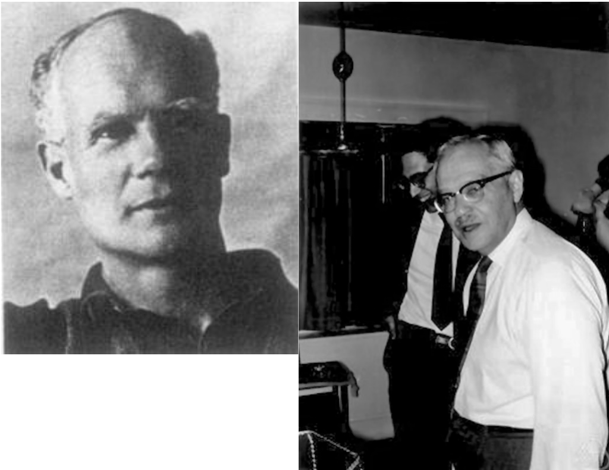

## Current statistical practice: Hybrid NHST

- Current statistical practice is a hybrid between the approaches of Fisher and Neyman-Pearson
- Gigerenzer ([2004](https://www.sciencedirect.com/science/article/pii/S1053535704000927)) introduces the term “null ritual” to denote current practices:
1. Setup a statistical null hypothesis, but do not specifiy your own hypothesis nor any alternative.
2. Use the 5% significance level for rejecting the null and accepting your hypothesis.
3. Always perform this procedure.

## Bayes-Laplace-Jeffreys

[figure not shown]

- Thomas Bayes (1701 - 1761)
  - Presbyterian minister & hobby mathematician
  - “An essay towards solving a Problem in the Doctrine of Chances” — **Bayes’ rule**
- Pierre-Simon Laplace (1749 - 1827)
  - “Newton of France”
  - Independently derived Bayes’ rule
  - Proved the central limit theorem
- Harold Jeffreys (1891 - 1989)
  - Revived the Bayesian view of probability in the 20th century
  - Developed the Bayes factor & default Bayesian hypotheses tests
- **Key Idea**: Use probability to quantify uncertainty about parameters, models, and hypotheses

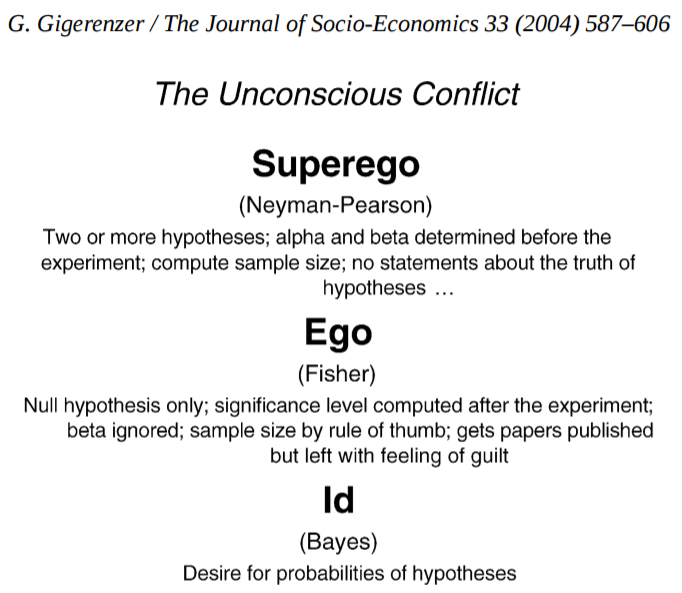

## Fundamental difference

- Probability is a branch of mathematics based on set theory, and as such uncontroversial
- However, there are different interpretations of probability
  - *Frequentist view:* Probability as the limit of relative frequency
  - *Bayesian view:* Probability as degree of belief
- What is the probability that Trump gets re-elected?
- What is the probability of a global temperature rise of 2°C in the 30 years?

## Frequentist interpretation

“The rational concept of probability, which is the only basis of probability calculus, applies only to problems in which either the same event repeats itself again and again … [In] order to apply the theory of probability we must have a practically unlimited sequence of observations.”

- Richard von Mises (quoted in Jackman, 2009, p. 5)

## Bayesian interpretation

“[I]n the conception we follow and sustain here, only *subjective* probabilities exist – i.e., the *degree of belief* in the occurrence of an event attributed by a given person at a given instant and with a given set of information.”

- Bruno de Finetti (quoted in Nau, 2001, p. 90)

## Why does it matter? Misunderstandings!

- This difference endows frequentist methods with a somewhat counter-intuitive air
- This is partly responsible for the many misunderstandings of statistical concepts
- Oakes (1986); Wulff et al. (1987); Haller & Krauss (2002); Lecoutre et al. (2003); Hoekstra et al. (2014)

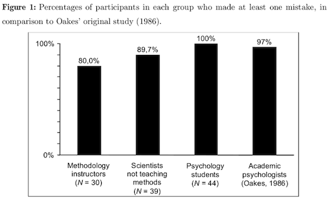

## Some bedtime readings

- Accessible popular science books that touch upon the history are
  - The Theory That Would Not Die (McGrayne, [2011](http://www.mcgrayne.com/the_theory_that_would_not_die__how_bayes__rule_cracked_the_enigma_code__hunted_d_107493.htm))
  - The Seven Pillars Of Statistical Wisdom (Stigler, [2016](https://www.goodreads.com/book/show/27311742-the-seven-pillars-of-statistical-wisdom))
  - Ten Great Ideas About Chance (Diaconis & Skyrms, [2017](https://press.princeton.edu/titles/11082.html); review [here](https://osf.io/xhmzj/))
  - The Empire of Chance (Gigerenzer et al., [1989](https://www.goodreads.com/book/show/786564.Empire_of_Chance))
  - The History of Statistics: The Measurement of Uncertainty before 1900 (Stigler, [1990](http://www.hup.harvard.edu/catalog.php?isbn=9780674403413))
- See also Fienberg (1992) for a review of six books about the history of probability

## Outline

- **1.** Some historical context
  - Fisher, Neyman-Pearson, Bayes-Laplace-Jeffreys
  - Two ways to interpret probabilities
- **2.** Recap of Probability
- **3.** Classical statistics
  - Maximum likelihood estimation
  - \(p\)-values, confidence intervals
- **4.** Bayesian statistics I
  - Estimation, testing, prediction
  - Bayes factor practicals in JASP
- **5.** Bayesian statistics II
  - Hint at Markov chain Monte Carlo
  - Bayesian workflow and model checking

## Two Rules of Probability

## Joint, Marginal, and Conditional probabilities

Consider the following table specifying the joint probability over eye and hair colour

```
##       blond brown  red black
## blue   0.22  0.21 0.00  0.01
## green  0.00  0.14 0.06  0.01
## brown  0.16  0.15 0.00  0.04
```

- We have \(P(\text{Eye}, \text{Hair})\)
  - What is the probability distribution over eye — \(P(\text{Eye})\)?
  - What is the probability distribution over hair — \(P(\text{Hair})\)?
  - What is the probability of hair, given eye colour blue — \(P(\text{Hair} \mid \text{Eye = blue})\)?

## Joint, Marginal, and Conditional probabilities

- Marginal distribution of Eye: \(P(\text{Eye}) = \sum_{h}^{n} P(\text{Eye}, \text{Hair = h})\)

```r
x[, 1] + x[, 2] + x[, 3] + x[, 4]
```

```
##  blue green brown
##  0.44  0.21  0.35
```

- Marginal distribution of Hair: \(P(\text{Hair}) = \sum_{e}^{m} P(\text{Hair}, \text{Eye = e})\)

```r
x[1, ] + x[2, ] + x[3, ]
```

```
## blond brown   red black
##  0.38  0.50  0.06  0.06
```

## Joint, Marginal, and Conditional probabilities

- Condititonal distribution over Hair, given blue eyes: Maybe it’s just this?

```r
x[1, ]
```

```
## blond brown   red black
##  0.22  0.21  0.00  0.01
```

- No! We have to renormalize — \(P(\text{Hair} \mid \text{Eye = blue}) = \frac{P(\text{Hair}, \text{Eye = blue})}{P(\text{Eye = blue})}\)

```r
x[1, ] / sum(x[1, ])
```

```
##      blond      brown        red      black
## 0.50000000 0.47727273 0.00000000 0.02272727
```

## Two rules of probability

- We saw the **sum rule** on the previous slide

\[ p(y) = \int_{\Theta} p(y, \theta) \, \mathrm{d}\theta \]

- The **product rule** states that

\[ p(\theta, y) = p(y \mid \theta) \,p(\theta) = p(\theta \mid y) \, p(y) \]

- From this, Bayes rule immediately follows

\[ \underbrace{p(\theta \mid y)}_{{\text{Posterior}}} = \frac{\overbrace{p(y \mid \theta)}^{\text{Likelihood}}\, \overbrace{p(\theta)}^{\text{Prior}}}{\underbrace{p(y)}_{\text{Marginal likelihood}}} = \frac{p(y \mid \theta) \, p(\theta)}{\int_{\Theta} p(y, \theta) \, \mathrm{d}\theta} \]

## Notation

- \(X\) is a random variable with realization \(x\)
- \(n\) realizations are \(\mathbf{x} = (x_1, \ldots, x_n)\)
- \(p(x)\) both for discrete and continuous random variables [\(P(X = x)\) and \(p(X = x)\)]
- \(p(\mathbf{x} \mid \theta)\) denotes a *likelihood function* relating parameter (vector) \(\theta\) to data \(\mathbf{x}\)
- We use \(\mathbb{E}[X]\) to denote the expectation of either a discrete or a continuous random variable, i.e.

\[ \begin{aligned} \mathbb{E}[X] &= \int_{X} x \, p(x) \, \mathrm{d}x \\[.5em] \mathbb{E}[X] &= \sum_{i=1}^n x_i \, p(x_i) \\ \end{aligned} \]

[figure not shown]

## Why most published research is false

|  | \(\mathcal{H}_0\) | \(\mathcal{H}_1\) |
| --- | --- | --- |
| reject \(\mathcal{H}_0\) | \(\alpha\) | \(1 - \beta\) |
| keep \(\mathcal{H}_0\) | 1 - \(\alpha\) | \(\beta\) |

## Exercise I

- What is the probability that my hypothesis is true, given that I have observed \(p < \alpha\)?
- Let’s say you have
  - Statistical power of \(\beta = 0.70\) for some effect size
  - Want to control error rates with \(\alpha = 0.05\)
  - Assume \(P(\mathcal{H}_1) = 0.20\)
  - Compute \(P(\mathcal{H}_1 \mid p < \alpha)\)!

## Why most published research is false

- What is the probability that my hypothesis is true, given that I have observed \(p < \alpha\)?
- Recall the product rule

\[ \begin{split} P(H_1|p < \alpha)P(p < \alpha) = P(H_1, p < \alpha) &= P(p < \alpha|H_1)P(H_1) \end{split} \]

- which leads to Bayes’ rule

\[ \begin{split} P(H_1|p < \alpha) &= \frac{P(p < \alpha|H_1)P(H_1)}{P(p < \alpha)} \\[1.5ex] &= \frac{P(p < \alpha|H_1)P(H_1)}{P(p < \alpha|H_1)P(H_1) + P(p < \alpha|H_0)P(H_0)} \end{split} \]

- Plugging in \(P(p < \alpha|H_1) = 1 - \beta\) and \(P(p < \alpha|H_0) = \alpha\)

\[ P(H_1|p < \alpha) = \frac{(1 - \beta) P(H_1)}{(1 - \beta) P(H_1) + \alpha (1 - P(H_1))} \]

## Why most published research is false

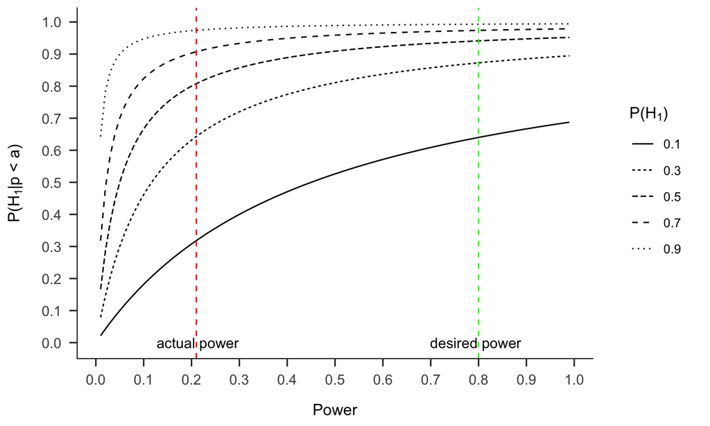

## Statistical models

## Statistical models

- Say I have a set of \(n = 100\) observations \(d = \{x_1, x_2, x_3, \ldots, x_n\}\)
- You ask me about the data; what can I tell you?

```r
d
```

```
##   [1] 107.97829  97.69310 105.68723  91.57817 100.68255  99.36588 113.81083
##   [8] 104.03224  87.80916  89.35512 110.42069  85.15186  97.48300 100.40710
##  [15]  99.52343 108.13351  76.99894  94.06699  97.02159  93.92357 121.06758
##  [22] 104.91280  92.48396 108.75160 104.85715 102.44135 107.42267 115.40291
##  [29] 105.29429 111.19024 100.96793  83.76809 101.20973 106.53400 103.20483
##  [36]  96.63230 112.29554  85.09677 119.74183  96.44044 110.73340 100.41942
##  [43] 105.36852 104.88455 106.27562  89.70382 104.66260  94.95458  89.90731
##  [50] 118.17459  90.85233 112.99377 103.12626  96.37302  92.45636  99.70174
##  [57]  97.29787  95.07651 116.58248  87.37510  89.91494  99.70467  97.43632
##  [64] 107.66106  85.73984 110.95736 101.22271 106.39446 104.21625  87.33096
##  [71]  93.35681 102.30501  97.05229  98.09652  96.22863 109.15487  94.86212
##  [78] 102.97085 106.76618 109.77560  81.26005  92.04866 101.85651  99.68925
##  [85] 101.97910  78.06927 114.79401  96.77466  98.15235 103.90206  95.19197
##  [92]  99.48015  98.22895  80.30618 101.59158  90.52129 105.40732  81.46523
##  [99]  97.32792 116.16882
```

## Statistical models

- Introduce a statistical model to reduce complexity
- A statistical model describes the relationship of one or more **parameters** and the observations \(d\)

\[ p(d \mid \mu, \sigma) = \prod_{i=1}^n \frac{1}{\sqrt{2\pi\sigma^2}} \exp \left(-\frac{1}{2\sigma} (x_i - \mu)^2 \right) \]

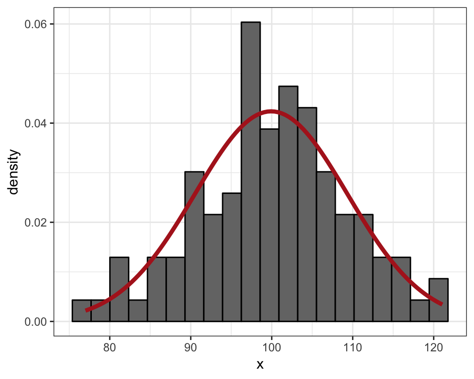

## Statistical models

- I used a normal distribution for the data
- Now I can describe the data with just two numbers — the mean \(\mu\) and the standard deviation \(\sigma\)

```r
c(mean(d), sd(d))
```

```
## [1] 99.931219  9.413697
```

- But there are other possible statistical models I could use!

## Statistical models

- Statistical models need not be appropriate; in fact, they can be horribly misspecified!

\[ p(d \mid a, b) = \prod_{i=1}^n \frac{1}{b - a} \]

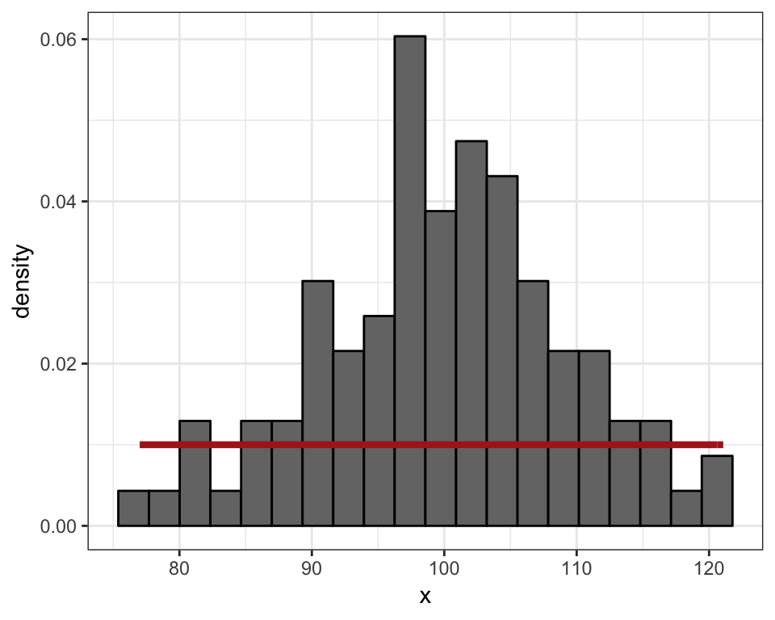

## Practical example

- **Data example**
  - We observe \(n = 20\) coin flips
  - \(y = 15\) show heads
  - Questions
    - Estimation: What are likely values for \(\theta\)?
    - Testing: Is the coin likely to be biased?
    - Prediction: How likely is the next coin toss to show heads?

| Problem | Classical statistics | Bayesian statistics |
| --- | --- | --- |
| Estimation | Maximum Likelihood, CIs | Posterior distribution (**Bayes’ rule**) |
| Testing | *p*-value | Bayes factor (**Bayes’ rule**) |
| Prediction | Plug-in Estimate | Account for uncertainty using **Bayes’ rule** |

## Binomial likelihood

\[ \begin{split} p(x \mid \theta) &\stackrel{\text{i.i.d.}}{=} p(x_1 \mid \theta) \cdot p(x_2 \mid \theta) \cdot \ldots \cdot p(x_n \mid \theta) \\ &= \prod^n_{i=1} p(x_i; \theta) \\ &= \prod^n_{i=1} \theta^{x_i} (1 - \theta)^{1 - x_i} \\ &= \theta^{\sum^n_{i = 1} x_i} (1 - \theta)^{\sum^n_{i = 1} 1 - x_i} \\[4ex] p(y \mid \theta, n) &= {n \choose y} \theta^{\sum^n_{i = 1} x_i} (1 - \theta)^{\sum^n_{i = 1} 1 - x_i} \hspace{3em} \text{Neglecting order} \\[1ex] &= {n \choose y} \theta^{y} (1 - \theta)^{n - y} \hspace{6.5em} \text{Introducing } Y = \sum^n_{i=1} x_i \\ \end{split} \]

## Classical approach

## Estimation: MLE

- A classic estimation method is maximum likelihood estimation

\[ \hat{\theta}_{\text{MLE}} = \underset{\theta}{\text{argmax}} \hspace{.5em} p(y \mid \theta) \]

“Objectivity is one of the principal reasons that frequentism dominated 20th century applications; a frequentist method like Wilcoxon’s test, which is completely devoid of prior opinion, has a clear claim to being objective – a crucial fact when scientists communicate with their skeptical colleagues.”

- Bradley Efron (2005, p. 4-5)

## Estimation: MLE

- A classic estimation method is the maximum likelihood estimation

\[ \hat{\theta}_{\text{MLE}} = \underset{\theta}{\text{argmax}} \hspace{.5em} p(y \mid \theta) \]

- **Exercise II**:
  - Can you give a Bayesian interpretation of this estimate?
  - That is, can you use Bayes’ rule in such a way that we get the MLE?

## Estimation

- Given the data (a random sample), what is the most likely population value \(\theta\)?
- We could apply different *estimators* to answer this question:
  - \(e_1(y, n) = y - n\)
  - \(e_2(y, n) = \frac{1}{2}\)
  - \(e_3(y, n) = \frac{y}{n} + \frac{1}{n}\)
  - \(e_4(y, n) = \frac{y}{n}\)
  - \(e_5(y, n) = \frac{y}{n} + 0.05 \cdot \left(-1\right)^{I\left(\frac{y}{n} > 0.50\right)}\)
- Compare them w.r.t.:
  - *bias*, *variance*,
  - *asymptotic bias*, *asymptotic variance / consistency*,
  - *asymptotic normality*, etc.

## Estimation

- The MLE \(\hat{\theta} = \frac{y}{n}\) has good properties (Stigler, 2007)

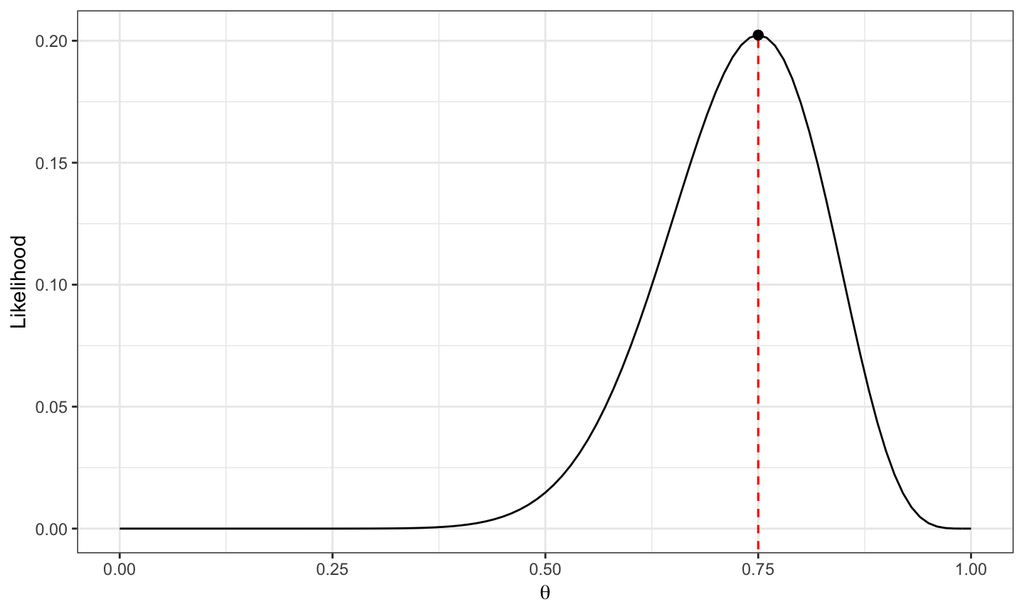

## Confidence intervals

- **Definition**. An X% confidence interval for a parameter \(\theta\) is an interval (L, U ) generated by a procedure that in repeated sampling has an X% probability of containing the true value of \(\theta\), for all possible values of \(\theta\) (Neyman, 1937).

“Consider now the case when a sample … is already drawn and the [confidence interval] given … Can we say that in this particular case the probability of the true value of [the parameter] falling between [the limits] is equal to [X%]? The answer is obviously in the negative.”

- Jerzy Neyman (quoted in Morey et al., 2015, p. 105)

## Confidence intervals

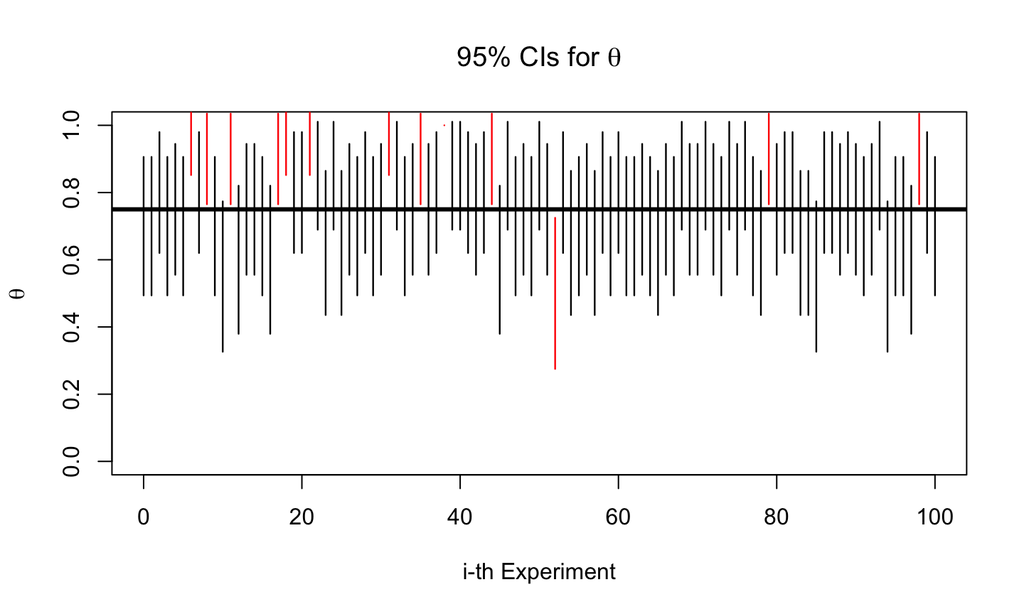

## Confidence intervals

“it is not suggested that we can ‘conclude’ that [the interval contains θ], nor that we should ‘believe’ that [the interval contains θ]…[we] decide to behave as if we actually knew that the true value [is in the interval]. This is done as a result of our decision and has nothing to do with ‘reasoning’ or ‘conclusion’. The reasoning ended when the [confidence procedure was derived]. The above process [of using CIs] is also devoid of any ‘belief’ concerning the value […] of [θ].”

- Jerzy Neyman (quoted in Morey et al., 2015, p. 106)

## Exercise III

**Can you construct a 50% confidence interval that is completely “meaningless”?**

## \(p\)-values

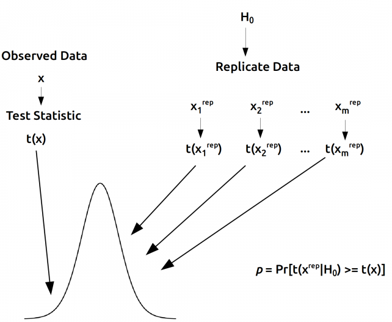

## \(p\)-values

- We replicate data under the assumption that \(H_0\) is true, i.e, \(\theta = .5\)

```r
conduct_experiment_h0 <- function(n) sum(rbinom(n, 1, prob = .5))
yrep <- replicate(100000, conduct_experiment_h0(n))

head(yrep, 10) # peak at some experiment outcomes
```

```
##  [1]  8 12 12 11  9 14 10  8  6 14
```

- Then we compute the probability that these data are at least as extreme as the one we observed

```r
mean(yrep >= y) * 2
```

```
## [1] 0.0401
```

## \(p\)-values

```r
binom.test(y, n)
```

```
##
##  Exact binomial test
##
## data:  y and n
## number of successes = 15, number of trials = 20, p-value = 0.04139
## alternative hypothesis: true probability of success is not equal to 0.5
## 95 percent confidence interval:
##  0.5089541 0.9134285
## sample estimates:
## probability of success
##                   0.75
```

## \(p\)-values

```r
res <- sapply(seq(20000), function(x) {
  dat <- rnorm(100, 0, 1)
  t.test(dat)$p.value
})
```

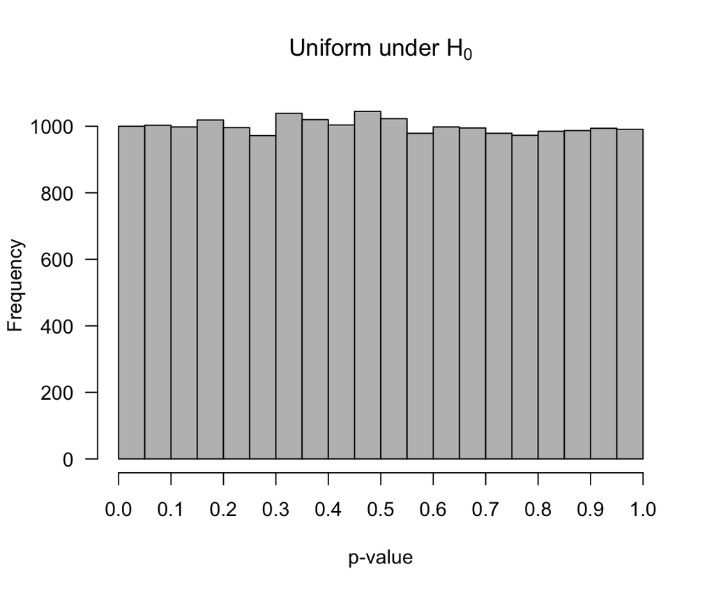

## Some issues with \(p\)-values

- \(p\)-values are uniformly distributed under \(H_0\)
  - This is by design, in order to have \(\alpha\)% of rejections under \(H_0\)
  - Therefore, however, \(p\)-values do not allow stating evidence in favour of \(H_0\)
- \(p\)-values are not really a means to compare models, but rather to check models
  - Conditional on the model (e.g., \(H_0\)), are the data surprising?
  - This is actuallly pretty cool, and we’ll come back to it
- Inference using \(p\)-values does not distinguish between being underpowered or \(H_1\) being true

## Some Literature

- Gigerenzer, G. ([2004](https://www.sciencedirect.com/science/article/abs/pii/S1053535704000927)). Mindless statistics. The Journal of Socio-Economics, 33(5), 587-606.
- Greenland, S., Senn, S. J., Rothman, K. J., Carlin, J. B., Poole, C., Goodman, S. N., & Altman, D. G. ([2016](https://link.springer.com/article/10.1007/s10654-016-0149-3)). Statistical tests, P values, confidence intervals, and power: a guide to misinterpretations. European Journal of Epidemiology, 31(4), 337-350.
- Morey, R. D., Hoekstra, R., Rouder, J. N., Lee, M. D., & Wagenmakers, E. J. ([2016](https://link.springer.com/article/10.3758/s13423-015-0947-8)). The fallacy of placing confidence in confidence intervals. Psychonomic bulletin & review, 23(1), 103-123.

## Bayesian approach

## Outline

- **1.** Bayesian estimation
  - Conjugate priors
  - Credible intervals
- **2.** Bayesian testing
  - Prior predictions and marginal likelihoods
  - Practical exercises in JASP

| Problem | Classical statistics | Bayesian statistics |
| --- | --- | --- |
| Estimation | Maximum Likelihood, CIs | Posterior distribution (**Bayes’ rule**) |
| Testing | *p*-value | Bayes factor (**Bayes’ rule**) |
| Prediction | Plug-in Estimate | Account for uncertainty using **Bayes’ rule** |

## Bayesian estimation

- Uses Bayes’ rule

\[ \underbrace{p(\theta \mid y)}_{{\text{Posterior}}} = \frac{\overbrace{p(y \mid \theta)}^{\text{Likelihood}}\, \overbrace{p(\theta)}^{\text{Prior}}}{\underbrace{p(y)}_{\text{Marginal likelihood}}} = \frac{p(y \mid \theta) \, p(\theta)}{\int_{\Theta} p(y, \theta) \, \mathrm{d}\theta} \]

- We know \(p(y \mid \theta)\) from our statistical setup
- How do we choose for \(p(\theta)\)?

## Beta prior distribution

\[ p(\theta \mid \alpha, \beta) = \frac{1}{\text{Beta}(\alpha, \beta)} \theta^{\alpha - 1}(1 - \theta)^{\beta - 1} \]

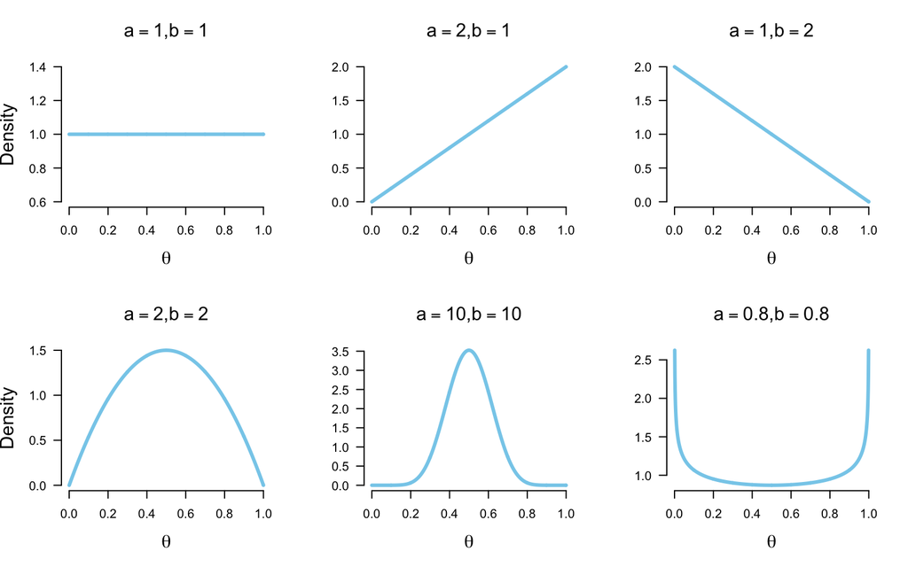

## Bayesian estimation

- [Computation on whiteboard]
- With some rearranging, we find that

\[ p(\theta \mid y) = \frac{1}{\text{Beta}(y + \alpha, n - y + \beta)} \theta^{y + \alpha - 1}(1 - \theta)^{n - y + \beta - 1} \]

## Conjugacy: Old joke

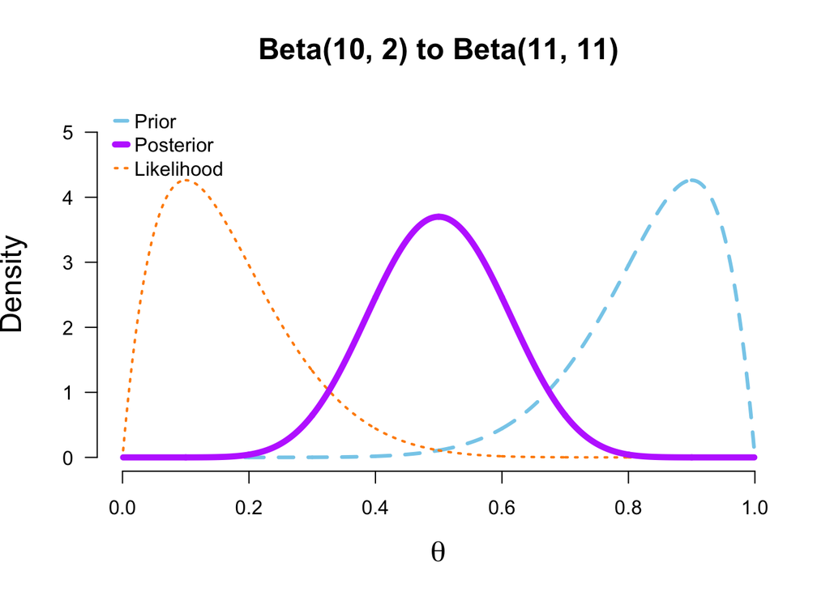

## Bayesian priors \(\equiv\) regularization

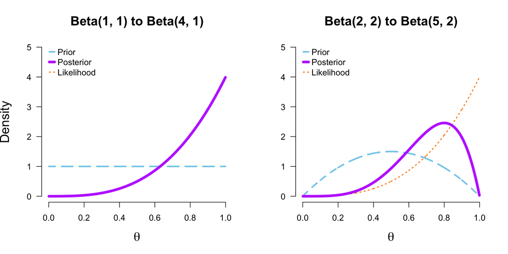

## Bayesian hypothesis testing

- In classical statistics, we test

\[ \mathcal{H}_0: \theta = 0.5 \\ \mathcal{H}_1: \theta \neq 0.5 \\ \]

- In Bayesian testing, we need to specify \(p(\theta \mid \mathcal{H}_1)\)
- It is through the prior that the model (which instantiates the hypothesis) makes predictions

\[ \begin{split} \mathcal{H}_0 &: \theta = 0.5 \\ \mathcal{H}_1 &: \theta \sim \text{Beta}(\alpha, \beta) \end{split} \]

- Bayesian hypothesis testing is about comparing the *prior predictive performance* of hypotheses
- It is **logically prior** to parameter estimation
  - First ask: is there an effect?
  - Then ask: how big is it?

## Prior predictive distribution

- The prior formalizes our uncertainty about \(\theta\) before seeing the data
- We get predictions by propagating this uncertainty:
  - First, we sample a value for \(\theta\) from the prior
  - Second, we use this sample to generate data from the likelihood
  - This results in a *prior predictive distribution*

```r
n <- 10
nr_draws <- 10e3
preds_m0 <- rbinom(nr_draws, n, prob = 0.5)

prior <- rbeta(nr_draws, 1, 1)
preds_m1 <- sapply(prior, function(theta) rbinom(1, n, theta))
```

## Prior predictive distribution

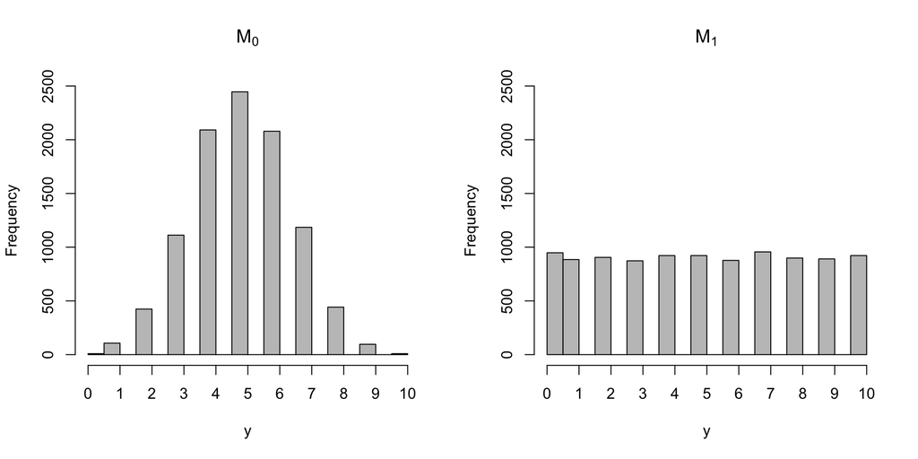

## Predictive performance of \(\mathcal{M}_0\)

- Look at predictions before seeing the data — *pre-dictive*

\[ \begin{aligned} p(y = 5 \mid \mathcal{M}_0) &= \int p(y = 5 \mid \theta, \mathcal{M}_1) \, p(\theta \mid \mathcal{M}_1) \, \mathrm{d}\theta \\[.5em] &= \int p(y = 5 \mid \theta, \mathcal{M}_0) \, \delta(\theta = 0.5) \, \mathrm{d}\theta \\[.5em] &= p(y = 5 \mid \theta = 0.5, \mathcal{M}_0) \\[.5em] &= {10 \choose 5} 0.5^5 (1 - 0.5)^5 \\[.5em] & = 0.25 \end{aligned} \]

## Predictive performance of \(\mathcal{M}_1\)

- For \(\mathcal{M}_1\), things are a little more complicated:

\[ \begin{aligned} p(y \mid \mathcal{M}_1) &= \int p(y \mid \theta, \mathcal{M}_1) \, p(\theta \mid \mathcal{M}_1) \, \mathrm{d}\theta \\[.5em] &= \int {n \choose y} \theta^y (1 - \theta)^{n - y} \frac{1}{\text{B}(a, b)} \theta^{a - 1} (1 - \theta)^{b - 1} \, \mathrm{d}\theta \\[1em] &= {n \choose y} \frac{1}{\text{B}(a, b)} \int \theta^y (1 - \theta)^{n - y} \theta^{a - 1} (1 - \theta)^{b - 1} \, \mathrm{d}\theta \\[1em] &= {n \choose y} \frac{1}{\text{B}(a, b)} \int \theta^{a + y - 1} (1 - \theta)^{b + n - y - 1} \, \mathrm{d}\theta \\[1em] &= {n \choose y} \frac{\text{B}(a + y, b + n - y)}{\text{B}(a, b)} \\[1em] &\rightarrow \frac{1}{11} \end{aligned} \]

## Bayesian model comparison

- How do we update our beliefs across models? \[ \begin{split} \underbrace{\frac{p(M_0 \mid y)}{p(M_1 \mid y)}}_{\text{Posterior odds}} &= \underbrace{\frac{p(y \mid M_0)}{p(y \mid M_1)}}_{\text{Bayes factor}} \, \times \underbrace{\frac{p(M_0)}{p(M_1)}}_{\text{Prior odds}} \\[1ex] \frac{p(M_0 \mid y)}{p(M_1 \mid y)} &= \frac{1 / 4}{1 / 11} \times \frac{1/2}{1/2} \approx 2.75 \end{split} \]

[figure not shown]

## Bayes factor

- is a great tool for model comparison
  - complex models can predict many data patterns
  - thus spread out their prior probability, \(p(\theta)\)
  - this gets factored into the marginal likelihood, \(\int p(y \mid \theta) \, p(\theta)\mathrm{d}\theta\), and decreases it
  - instantiates an **automatic Ockham’s razor**
- Bayes factors look at the functional form of the model, compared to
  - \(AIC = -2 \log p(\textbf{y} \mid \hat \theta) + 2\cdot k\)
  - \(BIC = -2 \log p(\textbf{y} \mid \hat \theta) + \log n \cdot k\)
- which penalize model complexity solely based on the number of parameters \(k\)

## Thermometer of evidence

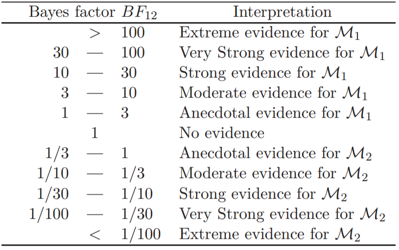

## Bayesian model comparison: Wrap-up

- Model = Prior + Likelihood makes predictions about future data
- Model’s predictive performance is given by how likely the observed data are under that model
  - Point priors = just the likelihood
  - Proper priors = integrate prior over likelihood
- Easy in conjugate settings
- Easy in low-dimensional settings

[figure not shown]

## Monte Carlo

- Monte Carlo integration:

\[ \begin{aligned} p(y \mid \mathcal{M}_1) &= \int p(y \mid \theta, \mathcal{M}_1) \, p(\theta \mid \mathcal{M}_1) \, \mathrm{d}\theta \\[.5em] &\approx \frac{1}{N} \sum_{i=1}^N p(y \mid \theta_i) \hspace{1em}\text{with} \hspace{1em} \theta_i \sim \text{Beta}(1, 1) \end{aligned} \]

```r
prior <- rbeta(nr_draws, 1, 1)
mean(dbinom(5, 10, prior))
```

```
## [1] 0.09102586
```

- This suffers from the *curse of dimensionality*:
  - With increasing number of parameters, the space in which the samples live grows exponentially

## Curse of dimensionality

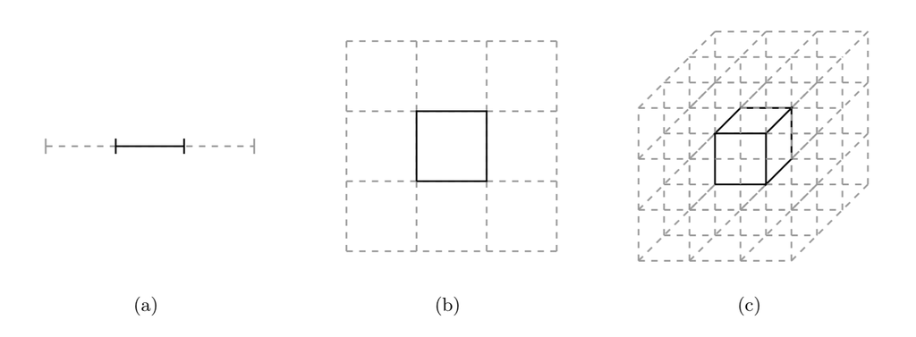

- See Betancourt ([2017](https://arxiv.org/abs/1701.02434))

## Bayesian posterior prediction

- [Computation on whiteboard]

| Problem | Classical statistics | Bayesian statistics |
| --- | --- | --- |
| Estimation | Maximum Likelihood, CIs | Posterior distribution (**Bayes’ rule**) |
| Testing | *p*-value | Bayes factor (**Bayes’ rule**) |
| Prediction | Plug-in Estimate | Account for uncertainty using **Bayes’ rule** |

## Bayesian posterior prediction

- Let \(y'\) denote the outcome of the next coin flip, and denote \(y\) as the observed data

## Bayesian priors \(\equiv\) regularization

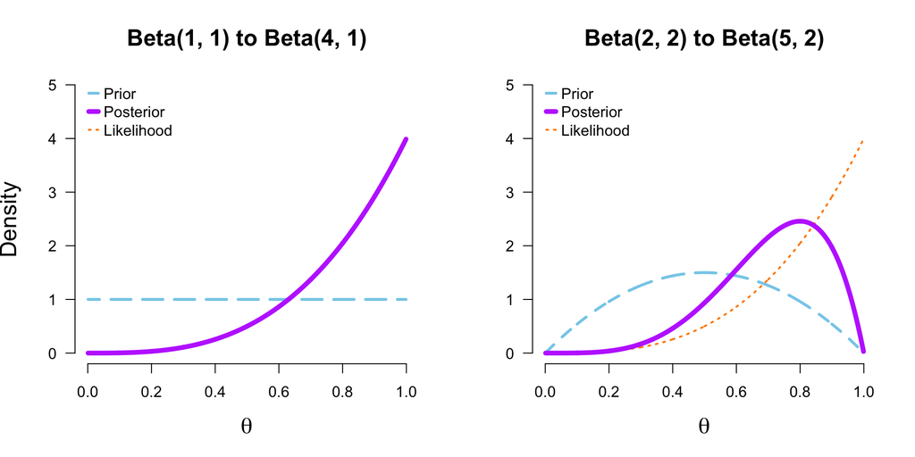

## Exercise IV

- .**(a)** Assume \(y = 15\) out of \(n = 20\) coin flips
- Compare the models

## Exercises IV

- .**(b)** Using uniform priors on models, compute the posterior model probabilities
  - Remove the best performing models and recompute the posterior model probabilities
    - Formally, what does this procedure do?
    - Does it make you feel a bit uncomfortable? Why? Why not?
    - What are the differences between posterior model probabilities and Bayes factors?
- .**(c)** Plot the posterior of \(\theta\) for the best model

\[ p(y' = 1 \mid y, \mathcal{M}) = \int p(y' = 1 \mid y, \theta, \mathcal{M}) \, p(\theta \mid y, \mathcal{M}) \, \mathrm{d}\theta \]

## Solutions (a)

```r
y <- 15
n <- 20
nsim <- 10e3
compute_pred <- function(prior) mean(sapply(prior, function(theta) dbinom(y, n, theta)))

pred1 <- dbinom(y, n, 0.50)
pred2 <- compute_pred(runif(nsim, 0, 1))
pred3 <- compute_pred(runif(nsim, .5, 1))
pred4 <- compute_pred(runif(nsim, 0, .5))

(preds <- c(pred1, pred2, pred3, pred4))
```

```
## [1] 0.014785767 0.047842480 0.094482410 0.001267485
```

## Solutions (b)

```r
model_prior <- 1/4

(model_posteriors <- model_prior * preds / (sum(model_prior * preds)))
```

```
## [1] 0.093357369 0.302077545 0.596562185 0.008002901
```

```r
(model_posteriors2 <- model_prior[-3] * preds[-3] / (sum(model_prior[-3] * preds[-3])))
```

```
## [1] 0.23140461 0.74875863 0.01983676
```

## Solutions (c)

```r
theta <- seq(0, 1, .001)
post_theta <- dunif(theta, .5, 1) * dbinom(y, n, theta)
post_theta <- post_theta / sum(post_theta)
```

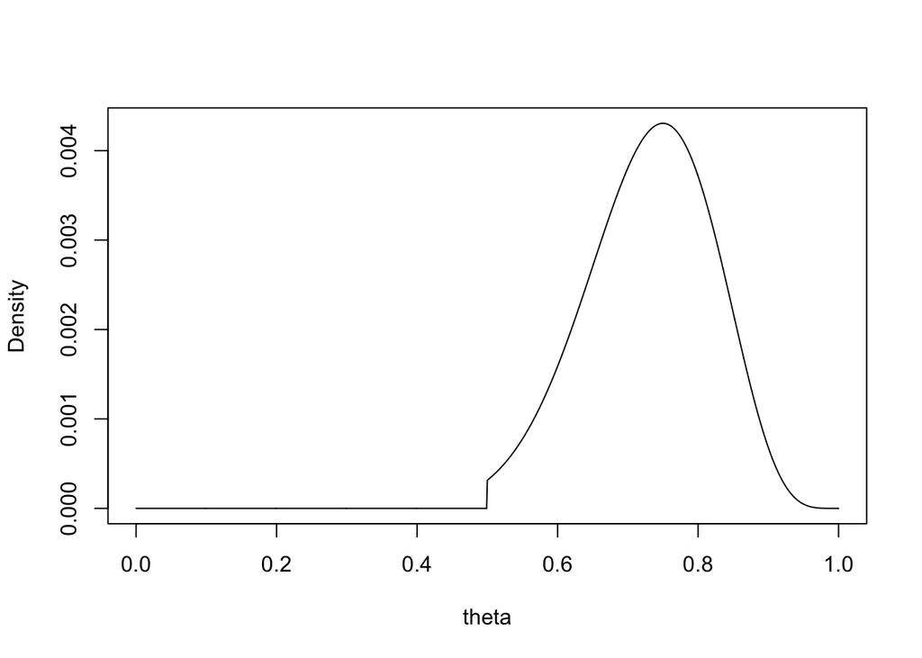

```r
plot(theta, post_theta, type = 'l', xlab = 'theta', ylab = 'Density')
```

## Markov chain Monte Carlo

- Computing \(p(\theta \mid y)\) is generally speaking very hard

\[ \underbrace{p(\theta \mid y)}_{{\text{Posterior}}} = \frac{\overbrace{p(y \mid \theta)}^{\text{Likelihood}}\, \overbrace{p(\theta)}^{\text{Prior}}}{\underbrace{p(y)}_{\text{Marginal likelihood}}} = \frac{p(y \mid \theta) \, p(\theta)}{\int_{\Theta} p(y, \theta) \, \mathrm{d}\theta} \]

- https://chi-feng.github.io/mcmc-demo/app.html
- Popularity of Bayesian methods is due to computational methods that sample efficiently from the posterior:
  - Chib, S., & Greenberg, E. ([1995](https://amstat.tandfonline.com/doi/abs/10.1080/00031305.1995.10476177)). Understanding the Metropolis-Hastings algorithm. The American Statistician, 49(4), 327-335.
  - Casella, G., & George, E. I. ([1992](https://www.tandfonline.com/doi/abs/10.1080/00031305.1992.10475878)). Explaining the Gibbs sampler. The American Statistician, 46(3), 167-174.
  - Betancourt, M. ([2017](https://arxiv.org/abs/1701.02434)). A conceptual introduction to Hamiltonian Monte Carlo. arXiv preprint arXiv:1701.02434.
  - Gronau, et al. ([2017](https://www.sciencedirect.com/science/article/pii/S0022249617300640)). A tutorial on bridge sampling. Journal of Mathematical Psychology, 81, 80-97.

## Bayesian hypothesis testing

## Thermometer of evidence

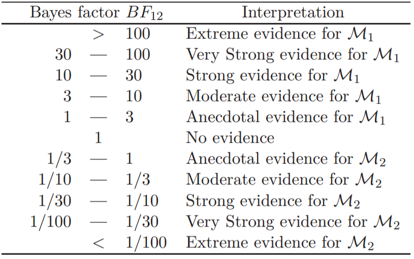

## Lindley’s Paradox

```r
k <- 49581
N <- 98451
```

\[ \mathcal{H}_0: \theta = .5 \\ \mathcal{H}_1: \theta \neq .5 \]

**\(p\)-value**

```
## [1] 0.02364686
```

\[ \begin{split} \mathcal{H}_0 &: \theta = .5 \\ \mathcal{H}_1 &: \theta \sim \text{Beta}(1, 1) \end{split} \]

**\(BF_{01}\)**

```
## [1] 19.21139
```

## What makes a good prior for testing?

- The Bayes factor is crucially sensitive to the prior over the ‘test-relevant’ parameter
  - The Bayes factor is a ratio of the average prior predictive success of two models
  - This prior sensitivity is completely obvious once one realizes that the prior *is part of the model*
  - If the prior is bad, the predictions are bad (example on board)

\[ p(y \mid \mathcal{M}_1) = \int_{\Theta} p(y \mid \theta, \mathcal{M}_1) \cdot p(\theta \mid \mathcal{M}_1) \mathrm{d}\theta \]

- Alright. So what makes a good prior for testing?

## What makes a good prior for testing?

- There are several desiderata that we want a Bayes factor to fulfill (Jeffreys, 1961; Ly et al., [2018](http://ejwagenmakers.com/2016/LyEtAl2016JMP.pdf))
  - Predictive matching
  - Information consistency
  - Model selection consistency
  - Label-invariance

## Correlation in JASP

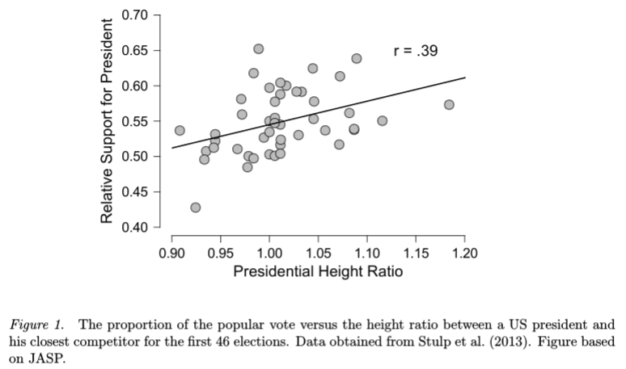

## Correlation in JASP

- **1** Load *Presidents.csv* into JASP. Run descriptive statistics and summarize what you find.
- **2** Conduct a classical correlation test.
  - **2a** Interpret the resulting *p*-value and confidence interval.
  - **2b** Are these concepts valid for the current data set? *Hint:* think about the data generating process.
- **3** Conduct a Bayesian correlation test.
  - **3a** Estimate the posterior distribution and interpret the Bayes factor.
  - **3b** Does the default prior in JASP make sense?
  - **3c** Run a robustness check. What do you conclude?
  - **3d** Run a sequential analysis. What do you conclude?

## t-test in JASP

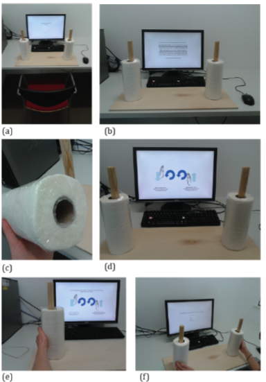

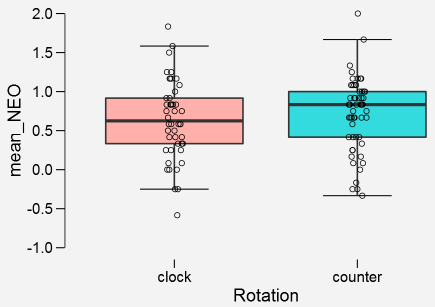

## t-test in JASP

- **1** Load *KitchenRolls.csv* into JASP. Run descriptive statistics and summarize the data graphically.
- **2** Conduct a classical t-test.
  - **2a** Interpret the resulting *p*-value and confidence interval.
  - **2b** Are these concepts valid for the current data set? *Hint:* think about the data generating process.
- **3** Conduct a Bayesian t-test.
  - **3a** Estimate the posterior distribution and interpret the Bayes factor.
  - **3b** Does the default prior in JASP make sense?
  - **3c** Run a robustness check. What do you conclude?
  - **3d** Run a sequential analysis. What do you conclude?
- **4** Conduct a Bayesian one-sided t-test. Is this approach justifiable?

## Linear regression

- Example: UScrime data set (aggregated)

```
##     M So  Ed Po1 Po2  LF  M.F Pop  NW  U1 U2 GDP Ineq    y
## 1 151  1  91  58  56 510  950  33 301 108 41 394  261  791
## 2 143  0 113 103  95 583 1012  13 102  96 36 557  194 1635
## 3 142  1  89  45  44 533  969  18 219  94 33 318  250  578
## 4 136  0 121 149 141 577  994 157  80 102 39 673  167 1969
## 5 141  0 121 109 101 591  985  18  30  91 20 578  174 1234
## 6 121  0 110 118 115 547  964  25  44  84 29 689  126  682
```

- Load it into JASP and run a regression predicting \(y\) using all other variables
- There’s a bunch of new stuff we haven’t touched on yet. Poke around, then we’ll discuss.

## Comparing theoretically motivated hypotheses

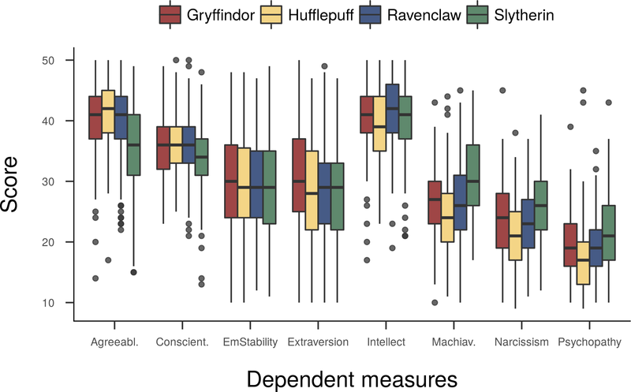

## Comparing theoretically motivated hypotheses

- Previous research has used a t-test comparing, say
  - Mean extraversion of Gryffindor with mean extraversion of Ravenclaw, Hufflepuff, Slytherin
  - This is not what we want!
- Using Bayesian inference, we can compare models with order-constraints on the mean

\[ \begin{split} \mathcal{M}_0 &: \mu_{\text{G}} = \mu_{\text{S}} = \mu_{\text{R}} = \mu_{\text{H}} \\ \mathcal{M}_f &: \mu_{\text{G}}, \, \mu_{\text{S}} , \, \mu_{\text{R}} , \, \mu_{\text{H}} \\ \mathcal{M}_r &: \mu_{\text{G}} > (\mu_{\text{S}} , \, \mu_{\text{R}} , \, \mu_{\text{H}}) \end{split} \]

## Some Literature

- DeGroot, M. H. (1982). Lindley’s paradox: Comment. Journal of the American Statistical Association, 77(378), 336-339.
- Ly, A., Verhagen, A. J., & Wagenmakers, E.-J. ([2016](https://www.sciencedirect.com/science/article/abs/pii/S0022249615000383)). Harold Jeffreys’s default Bayes factor hypothesis tests: Explanation, extension, and application in psychology. Journal of Mathematical Psychology, 72, 19-32.
- Ly, A., et al. ([2019](https://psyarxiv.com/dhb7x)). The Bayesian Methodology of Sir Harold Jeffreys as a Practical Alternative to the P-value Hypothesis Test. Pre-print.

## Bayesian workflow

## Workflow

- Specify the likelihood
- Choose priors
  - Do they make substantive sense?
  - Can we constrain them logically?
  - Can we base them on prior data / modeling?
  - Does the resulting *prior predictive distribution* make sense?
- Estimate on data
  - Compare with other models
  - Do *posterior predictions* make sense?
- For a case study, see https://fdabl.github.io/r/Law-of-Practice.html

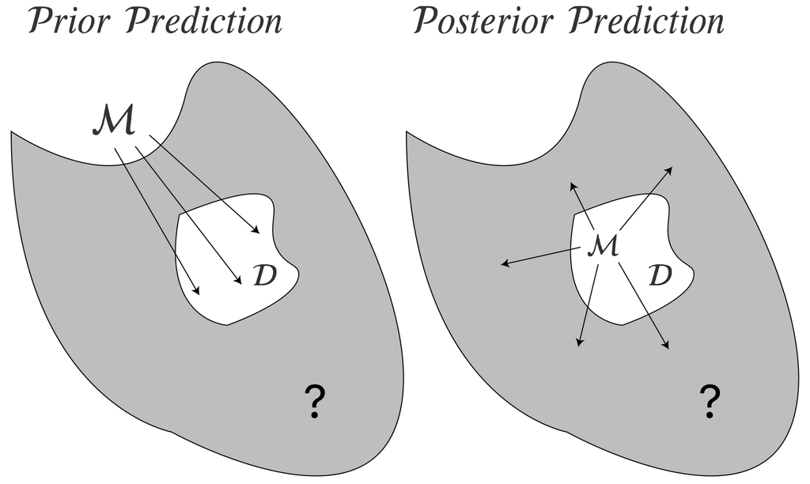

## A post-dictive perspective

- Bayes factors consider a model’s prediction before seeing data
- Leave-one-out (Loo) cross-validation considers predictions after seeing data
- Let \((x_1, x_2, \ldots, x_n)\) denote \(n\) observations
- We compute the Loo score of a model by writing

\[ \begin{aligned} \hat{\text{elpd}}_{\text{loo}}^{\mathcal{M}} &= \sum_{i=1}^n \, \text{log} \, p(x_i \mid x_{-i}) \\[.5em] &= \sum_{i=1}^n \int \text{log} \, p(x_i, \theta \mid x_{-i}) \, \mathrm{d}\theta \\[.5em] &= \sum_{i=1}^n \int \text{log} \, \left[p(x_i \mid \theta) \, p(\theta \mid x_{-i}) \right]\, \mathrm{d}\theta \end{aligned} \]

- For details, see Gelman et al. ([2014](https://arxiv.org/abs/1307.5928)) & Vehtari et al. ([2017](https://arxiv.org/abs/1507.04544))

## Contrast: Bayes factors & Loo

- **Bayes factors** are
  - *pre-dictive*
  - Model selection consistent
  - Highly dependent on the priors
  - What probability dictates (have a nice interpretation)
  - \(\mathcal{M}\)-closed?
  - Hard to compute
- **Loo** is
  - *post-dictive*
  - Model selection inconsistent
  - No strong dependence on the priors
  - \(\mathcal{M}\)-open
  - Easy to compute
- For recent discussions, see Gronau & Wagenmakers ([2019](https://link.springer.com/article/10.1007/s42113-018-0011-7)) & Vehtari et al. ([2019](https://link.springer.com/article/10.1007/s42113-018-0020-6))

## Posterior predictive checking

- *p*-values are a good tool for model checking
  - Assuming the model is true, are the data surprising?

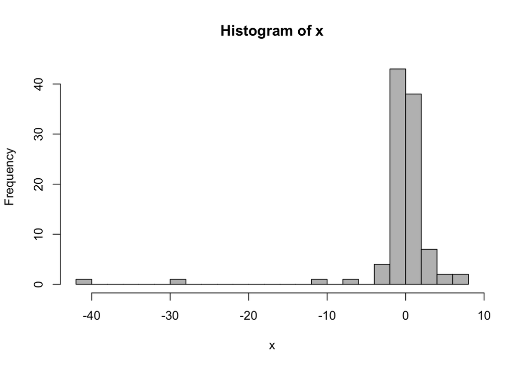